# DeSimone_MS64060_Assignment 5

Heather DeSimone

4/9/2022

##First I have loaded in my data frame and removed the cereals that are missing information.

```r
library(dplyr)
library(caret)
library(class)
library(ISLR)
library(tidyverse)
library(factoextra)
library(stats)
DF=read.csv("C:/Users/hdesi/Desktop/MBA/Machine Learning/Cereals.csv")
DF <- na.omit(DF) ##Remove cereals missing data
DF$mfr<-NULL ##Not needed
DF$type<-NULL ##Not needed
rownames(DF) <- DF$name ##Change row name to cereal name rather than numeric value
DF$name<-NULL
head(DF)
```

```
##                           calories protein fat sodium fiber carbo sugars potass
## 100%_Bran                       70       4   1    130  10.0   5.0      6    280
## 100%_Natural_Bran              120       3   5     15   2.0   8.0      8    135
## All-Bran                        70       4   1    260   9.0   7.0      5    320
## All-Bran_with_Extra_Fiber       50       4   0    140  14.0   8.0      0    330
## Apple_Cinnamon_Cheerios        110       2   2    180   1.5  10.5     10     70
## Apple_Jacks                    110       2   0    125   1.0  11.0     14     30
##                           vitamins shelf weight cups   rating
## 100%_Bran                       25     3      1 0.33 68.40297
## 100%_Natural_Bran                0     3      1 1.00 33.98368
## All-Bran                        25     3      1 0.33 59.42551
## All-Bran_with_Extra_Fiber       25     3      1 0.50 93.70491
## Apple_Cinnamon_Cheerios         25     1      1 0.75 29.50954
## Apple_Jacks                     25     2      1 1.00 33.17409
```

```r
sapply(DF, class) ##Making sure variables are numerical
```

```
##  calories   protein       fat    sodium     fiber     carbo    sugars    potass
## "integer" "integer" "integer" "integer" "numeric" "numeric" "integer" "integer"
##  vitamins     shelf    weight      cups    rating
## "integer" "integer" "numeric" "numeric" "numeric"
```

##Creating data frame for normalization

```r
DF.norm <- data.frame(DF)

head(DF.norm)
```

```
##                           calories protein fat sodium fiber carbo sugars potass
## 100%_Bran                       70       4   1    130  10.0   5.0      6    280
## 100%_Natural_Bran              120       3   5     15   2.0   8.0      8    135
## All-Bran                        70       4   1    260   9.0   7.0      5    320
## All-Bran_with_Extra_Fiber       50       4   0    140  14.0   8.0      0    330
## Apple_Cinnamon_Cheerios        110       2   2    180   1.5  10.5     10     70
## Apple_Jacks                    110       2   0    125   1.0  11.0     14     30
##                           vitamins shelf weight cups   rating
## 100%_Bran                       25     3      1 0.33 68.40297
## 100%_Natural_Bran                0     3      1 1.00 33.98368
## All-Bran                        25     3      1 0.33 59.42551
## All-Bran_with_Extra_Fiber       25     3      1 0.50 93.70491
## Apple_Cinnamon_Cheerios         25     1      1 0.75 29.50954
## Apple_Jacks                     25     2      1 1.00 33.17409
```

##I will perform hierarchical clustering using Euclidean Distance

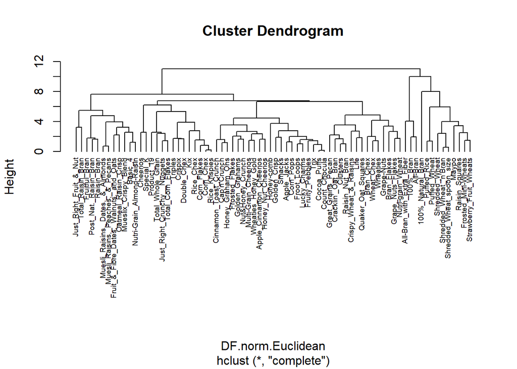

```r
DF.norm <- scale(DF) ##Data normalization
DF.norm.Euclidean <- dist(DF.norm, method = "euclidean")
hc1 <- hclust(DF.norm.Euclidean, method = "complete")

plot(hc1, cex = .6, hang = -1) ##Plotting the cluster Dendrogram using all variables still in dataset
```

##I will now use Agnes to compare clustering methods to find the best one

```r
library(cluster)
hc_single <- agnes(DF.norm, method = "single")
hc_complete <- agnes(DF.norm, method = "complete")
hc_average <- agnes(DF.norm, method = "average")
hc_ward <- agnes(DF.norm, method = "ward") ##Ward is the best method

print(hc_single$ac)
```

```
## [1] 0.6067859
```

```r
print(hc_complete$ac)
```

```
## [1] 0.8353712
```

```r
print(hc_average$ac)
```

```
## [1] 0.7766075
```

```r
print(hc_ward$ac) ##closest to 1
```

```
## [1] 0.9046042
```

##I will now create my Agnes Dendrogram

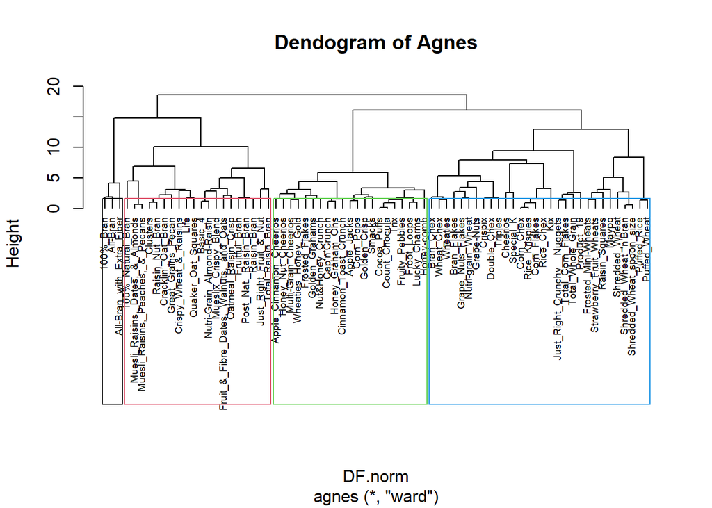

```r
pltree(hc_ward, cex = 0.6, hang = -1, main = "Dendogram of Agnes")
rect.hclust(hc_ward, k = 4, border = 1:4) ##4 clusters
```

##Now I want to cluster my data by unhealthy variables. For our purposes, we will assume that cereals high in calories, fat, sugar, and sodium are unhealthy.

```r
DF.Unhealthy <- DF[c(1,3,4,7)] ##Calories, fat, sodium, sugar
head(DF.Unhealthy)
```

```
##                           calories fat sodium sugars
## 100%_Bran                       70   1    130      6
## 100%_Natural_Bran              120   5     15      8
## All-Bran                        70   1    260      5
## All-Bran_with_Extra_Fiber       50   0    140      0
## Apple_Cinnamon_Cheerios        110   2    180     10
## Apple_Jacks                    110   0    125     14
```

##Finding best Agnes method

```r
unhealthy_single <- agnes(DF.Unhealthy, method = "single")
unhealthy_complete <- agnes(DF.Unhealthy, method = "complete")
unhealthy_average <- agnes(DF.Unhealthy, method = "average")
unhealthy_ward <- agnes(DF.Unhealthy, method = "ward") ##Best method

print(unhealthy_single$ac)
```

```
## [1] 0.7794119
```

```r
print(unhealthy_complete$ac)
```

```
## [1] 0.967792
```

```r
print(unhealthy_average$ac)
```

```
## [1] 0.9423144
```

```r
print(unhealthy_ward$ac)
```

```
## [1] 0.9868955
```

##Ward was the best method for clustering. Now we will create our dendograph to look at our clusters for unhealthy variables.

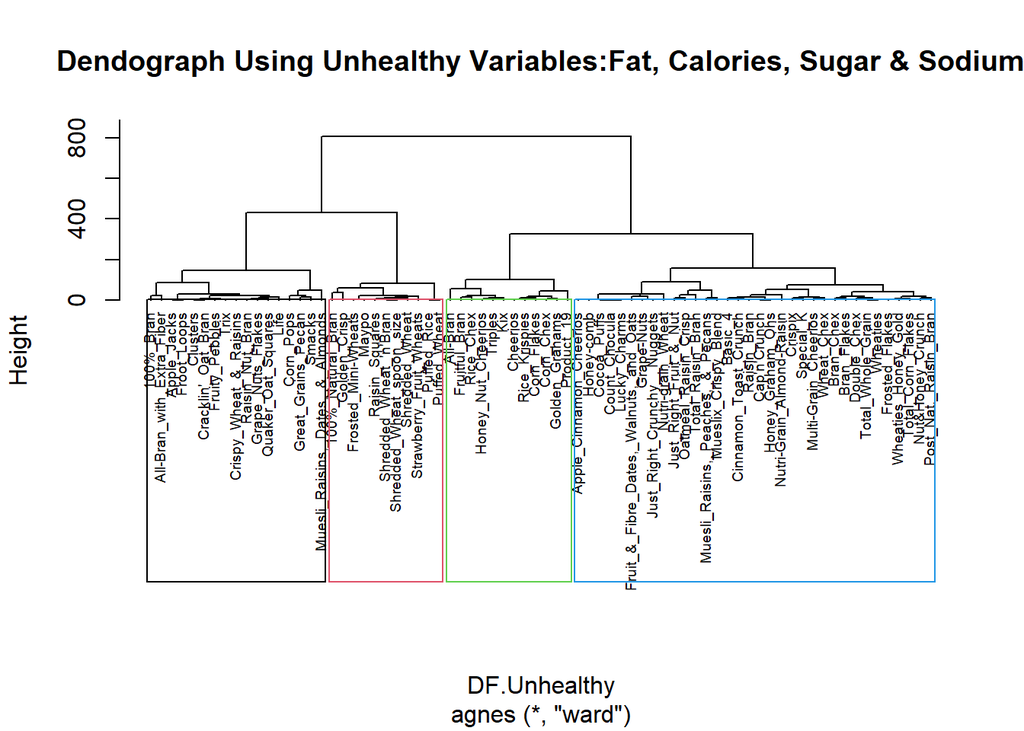

```r
pltree(unhealthy_ward, cex = 0.6, hang = -1, main = "Dendograph Using Unhealthy Variables:Fat, Calories, Sugar & Sodium")
rect.hclust(unhealthy_ward, k = 4, border = 1:4)
```

##Now we will cluster based on healthy variables. Those high in protein, fiber, and vitamins are most healthy.

```r
DF.Healthy <- DF[c(2,5,9)] ##Protein, fiber, vitamins
head(DF.Healthy)
```

```
##                           protein fiber vitamins
## 100%_Bran                       4  10.0       25
## 100%_Natural_Bran               3   2.0        0
## All-Bran                        4   9.0       25
## All-Bran_with_Extra_Fiber       4  14.0       25
## Apple_Cinnamon_Cheerios         2   1.5       25
## Apple_Jacks                     2   1.0       25
```

##Finding best Agnes method

```r
healthy_single <- agnes(DF.Healthy, method = "single")
healthy_complete <- agnes(DF.Healthy, method = "complete")
healthy_average <- agnes(DF.Healthy, method = "average")
healthy_ward <- agnes(DF.Healthy, method = "ward")##Best method

print(healthy_single$ac)
```

```
## [1] 0.9950214
```

```r
print(healthy_complete$ac)
```

```
## [1] 0.9957495
```

```r
print(healthy_average$ac)
```

```
## [1] 0.9948298
```

```r
print(healthy_ward$ac)
```

```
## [1] 0.9983455
```

##Ward was the best method for clustering. Now we will create our dendograph to look at our clusters for healthy variables.

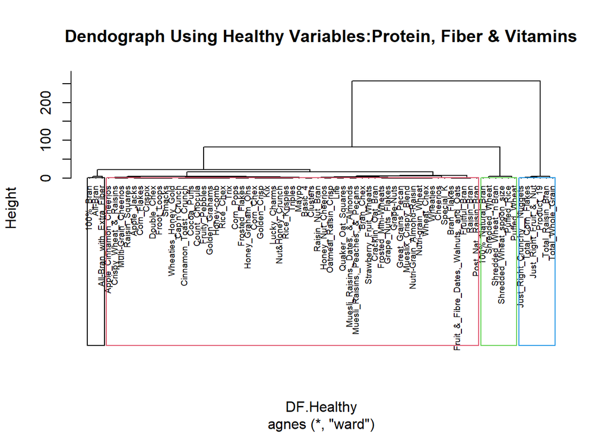

```r
pltree(healthy_ward, cex = 0.6, hang = -1, main = "Dendograph Using Healthy Variables:Protein, Fiber & Vitamins")
rect.hclust(healthy_ward, k = 4, border = 1:4)
```

##Clustering is a bit uneven, but it looks like cluster 1 (Black) is the healthiest and there are repeat cereals in this healthy cluster that were also in the healthy cluster is our last dendograph

##Now we will look at all of our health related variables together. Our cluster will consist of protein, fiber, vitamins, calories, fat, sugar, and sodium

```r
DF.TotalHealth <- DF[c(1,2,3,4,5,7,9)]
head(DF.TotalHealth)
```

```
##                           calories protein fat sodium fiber sugars vitamins
## 100%_Bran                       70       4   1    130  10.0      6       25
## 100%_Natural_Bran              120       3   5     15   2.0      8        0
## All-Bran                        70       4   1    260   9.0      5       25
## All-Bran_with_Extra_Fiber       50       4   0    140  14.0      0       25
## Apple_Cinnamon_Cheerios        110       2   2    180   1.5     10       25
## Apple_Jacks                    110       2   0    125   1.0     14       25
```

##Finding best Agnes

```r
TotalHealth_single <- agnes(DF.TotalHealth, method = "single")
TotalHealth_complete <- agnes(DF.TotalHealth, method = "complete")
TotalHealth_average <- agnes(DF.TotalHealth, method = "average")
TotalHealth_ward <- agnes(DF.TotalHealth, method = "ward") ##Best Method

print(TotalHealth_single$ac)
```

```
## [1] 0.8615331
```

```r
print(TotalHealth_complete$ac)
```

```
## [1] 0.9604174
```

```r
print(TotalHealth_average$ac)
```

```
## [1] 0.9306789
```

```r
print(TotalHealth_ward$ac)
```

```
## [1] 0.9837845
```

##Ward is again the best method. Now we will look at our dendograph in which we clustered based on all health variables (good and bad)

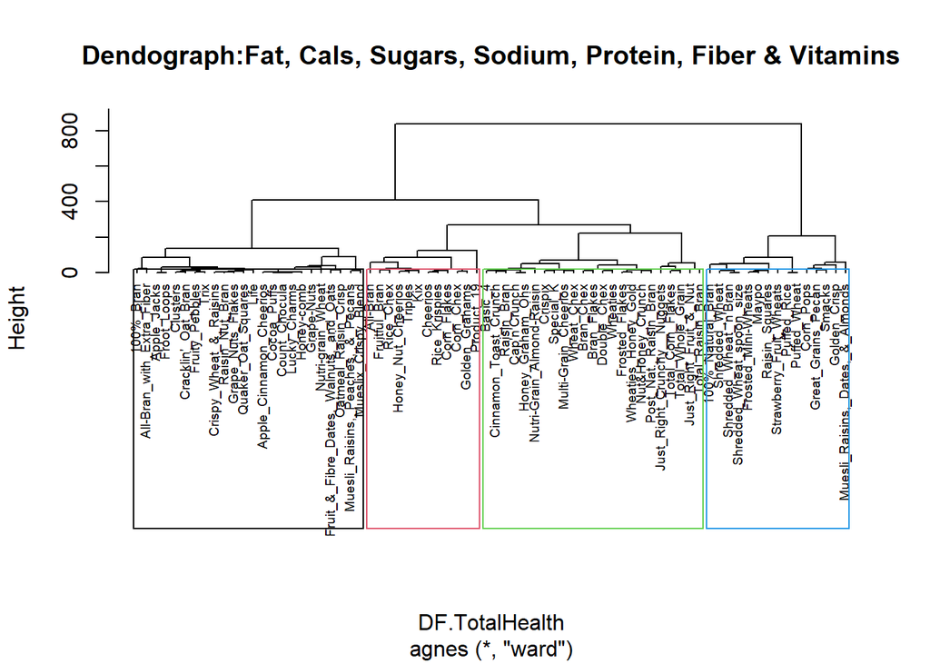

```r
pltree(TotalHealth_ward, cex = 0.6, hang = -1, main = "Dendograph:Fat, Cals, Sugars, Sodium, Protein, Fiber & Vitamins")
rect.hclust(TotalHealth_ward, k = 4, border = 1:4)
```

##I want to create more than 4 cluster using this same overall health model

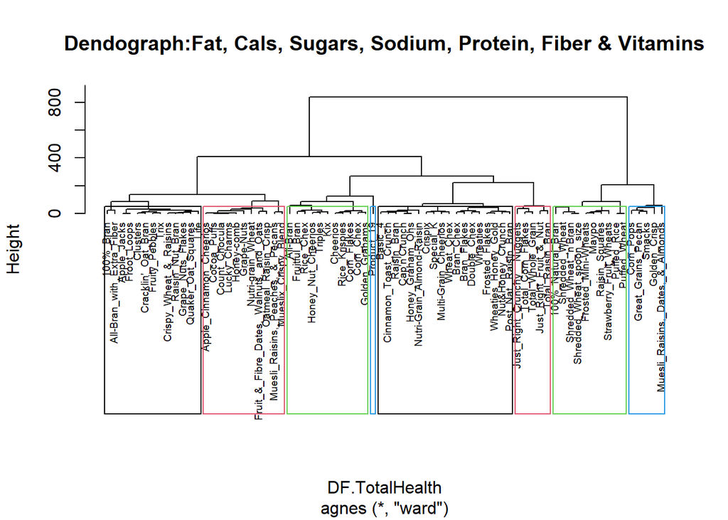

```r
pltree(TotalHealth_ward, cex = 0.6, hang = -1, main = "Dendograph:Fat, Cals, Sugars, Sodium, Protein, Fiber & Vitamins")
rect.hclust(TotalHealth_ward, k = 8, border = 1:4) ##8 clusters
```

##This 8 cluster model gives us a much more condensed list. With 100% bran in all of our dendograph healthy clusters, we will assume that the cluster this cereal falls into is the healthiest group - based on sugar, fat, calories, sodium, protein, fiber, and vitamins. The school could use any of these dendographs to base their decision on, depending on what they are looking for and what they consider healthy. Some people feel that a diet low in calories, fat, sugar, and sodium is healthy even if those foods are low in nutrients. Some people feel that a diet high in vitamins, fiber, and protein are healthy even if they have higher calories, fat, sugar. and sodium. I believe that the last dendograph should be used (8 clusters) as it takes all of these variables into consideration.